# National and Subnational estimates for the United Kingdom

Subnational estimates Europe United Kingdom

Estimates presented here are no longer updated as of 31 March 2022. For more information on the rationale behind this move and some reflections on 2 years of global nowcasting and forecasting, please read our related [blog post](https://epiforecasts.io/posts/2022-03-25-rt-reflections/).

Katharine Sherratt*, Sam Abbott*, Sophie R Meakin, Joel Hellewell, James D Munday, Nikos Bosse, CMMID Covid-19 working group, Mark Jit, Sebastian Funk (Centre for Mathematical Modelling of Infectious Diseases, London School of Hygiene & Tropical Medicine)  
2020-10-20

*Using data available up to the 2022-03-26*

We track transmission of Covid-19 in the United Kingdom using estimates of the time-varying reproduction number from a range of data sources (including test positive cases, hospital admissions, and death data) and spatial scales (national, regional (devolved authority and NHS region level in England), and local authority level). Where data is available these estimates are updated each day and published to a [publicly available archive](https://dataverse.harvard.edu/dataverse/covid-rt) under an open source license. Estimates are also available from GitHub ([subnational estimates](https://github.com/epiforecasts/covid-rt-estimates/tree/master/subnational/united-kingdom/), [UTLA estimates](https://github.com/epiforecasts/covid-rt-estimates/blob/master/subnational/united-kingdom-local/cases/summary/rt.csv), [national estimates](https://github.com/epiforecasts/covid-rt-estimates/tree/master/national/cases/summary), and [collated estimates](https://github.com/epiforecasts/covid-rt-estimates/blob/master/subnational/united-kingdom/collated/rt.csv)).

See our [Methods](https://epiforecasts.io/covid/methods) or our [paper](https://wellcomeopenresearch.org/articles/5-112/) for an explanation of how these estimates are derived, and our [pre-print](https://www.medrxiv.org/content/10.1101/2020.10.18.20214585v1) for methods comparing Rt estimates by data source. If interested in producing interactive visualisations of these estimates to be shown on this page please open an issue [here](https://github.com/epiforecasts/covid/issues).

## National summary

### Summary (estimates as of the 2022-03-26)

*Table 1: Latest estimates (as of the 2022-03-26) of the number of confirmed cases by date of infection, the expected change in daily confirmed cases, the effective reproduction number, the growth rate, and the doubling time (when negative this corresponds to the halving time). The median and 90% credible interval is shown for each numeric estimate.*

|  | Estimate |
| --- | --- |
| New confirmed cases by infection date | 18984 (7247 – 41104) |
| Expected change in daily cases | Decreasing |
| Effective reproduction no. | 0.5 (0.25 – 0.81) |
| Rate of growth | -0.15 (-0.24 – -0.054) |
| Doubling/halving time (days) | -4.6 (-13 – -2.9) |

### Confirmed cases, their estimated date of report, date of infection, and time-varying reproduction number estimates

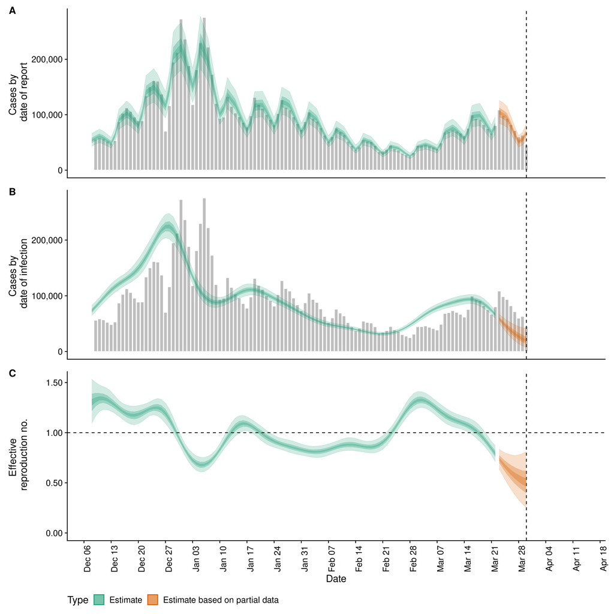

*Figure 1: A.) Confirmed cases by date of report (bars) and their estimated date of report. B.) Confirmed cases by date of report (bars) and their estimated date of infection. C.) Time-varying estimate of the effective reproduction number (lightest ribbon = 90% credible interval; darker ribbon = the 50% credible interval, darkest ribbon = 20% credible interval). Estimates from existing data are shown up to the 2022-03-26 from when forecasts are shown. These should be considered indicative only. Estimates based on partial data have been adjusted for right truncation of infections. The vertical dashed line indicates the date of report generation. Uncertainty has been curtailed to a maximum of ten times the maximum number of reported cases for plotting purposes.*

## Subnational breakdown

Regional

Expected daily confirmed cases by NHSE region and devolved nation

[interactive chart not shown]

*Figure 2: The results of the latest reproduction number estimates (based on confirmed cases in United Kingdom, stratified by NHSE Region / devolved nation, can be summarised by whether confirmed cases are likely increasing or decreasing. This represents the strength of the evidence that the reproduction number in each region is greater than or less than 1, respectively (see the [methods](https://epiforecasts.io/covid/methods.html) for details).*

| NHSE Region / devolved nation | New confirmed cases by infection date | Expected change in daily cases | Effective reproduction no. | Rate of growth | Doubling/halving time (days) | New confirmed cases by infection date | Effective reproduction no. | Rate of growth | Doubling/halving time (days) |
| --- | --- | --- | --- | --- | --- | --- | --- | --- | --- |
| East of England | 6848 (3179 -- 15428) | Likely decreasing | 0.91 (0.56 -- 1.5) | -0.024 (-0.13 -- 0.12) | -29 (5.7 -- -5.4) | 6848 | 0.91 | -0.024 | -29 |
| England | 60177 (28158 -- 133869) | Stable | 0.94 (0.59 -- 1.5) | -0.016 (-0.12 -- 0.13) | -44 (5.5 -- -5.7) | 60177 | 0.94 | -0.016 | -44 |
| London | 7450 (3228 -- 18184) | Stable | 0.94 (0.55 -- 1.6) | -0.018 (-0.13 -- 0.16) | -39 (4.5 -- -5.2) | 7450 | 0.94 | -0.018 | -39 |
| Midlands | 12102 (6231 -- 24177) | Stable | 0.99 (0.66 -- 1.5) | -0.0024 (-0.099 -- 0.12) | -290 (5.6 -- -7) | 12102 | 0.99 | -0.0024 | -290 |
| North East and Yorkshire | 8461 (4294 -- 17135) | Stable | 0.96 (0.64 -- 1.4) | -0.01 (-0.11 -- 0.12) | -66 (6 -- -6.6) | 8461 | 0.96 | -0.01 | -66 |
| North West | 7243 (3351 -- 15199) | Stable | 0.95 (0.59 -- 1.5) | -0.013 (-0.12 -- 0.12) | -52 (5.8 -- -5.8) | 7243 | 0.95 | -0.013 | -52 |
| Northern Ireland | 693 (256 -- 1708) | Decreasing | 0.57 (0.29 -- 1) | -0.13 (-0.23 -- 0.0017) | -5.5 (400 -- -3.1) | 693 | 0.57 | -0.13 | -5.5 |
| Scotland | 8470 (3886 -- 18956) | Likely decreasing | 0.93 (0.58 -- 1.4) | -0.019 (-0.12 -- 0.12) | -36 (6 -- -5.7) | 8470 | 0.93 | -0.019 | -36 |
| South East | 9961 (4987 -- 20271) | Likely decreasing | 0.89 (0.58 -- 1.4) | -0.032 (-0.12 -- 0.094) | -22 (7.4 -- -5.6) | 9961 | 0.89 | -0.032 | -22 |
| South West | 7101 (3485 -- 14296) | Likely decreasing | 0.87 (0.56 -- 1.3) | -0.038 (-0.13 -- 0.083) | -18 (8.3 -- -5.2) | 7101 | 0.87 | -0.038 | -18 |

[output cut: 2 more lines]

*Table 2: Latest estimates (as of the 2022-03-26) of the number of confirmed cases by date of infection, the effective reproduction number, the rate of growth, and the doubling time (when negative this corresponds to the halving time) in each region. The median and 90% credible interval is shown.*

Local

Estimates are shown at the level of Upper Tier Local Authorities (UTLAs).

[interactive chart not shown]

*Figure 3: The results of the latest reproduction number estimates (based on confirmed cases in United Kingdom, stratified by UTLA, can be summarised by whether confirmed cases are likely increasing or decreasing. This represents the strength of the evidence that the reproduction number in each region is greater than or less than 1, respectively (see the [methods](https://epiforecasts.io/covid/methods.html) for details).*

| UTLA | New confirmed cases by infection date | Expected change in daily cases | Effective reproduction no. | Rate of growth | Doubling/halving time (days) | New confirmed cases by infection date | Effective reproduction no. | Rate of growth | Doubling/halving time (days) |
| --- | --- | --- | --- | --- | --- | --- | --- | --- | --- |
| Aberdeen City | 322 (92 -- 1200) | Stable | 0.99 (0.7 -- 1.3) | -0.0038 (-0.088 -- 0.075) | -180 (9.2 -- -7.9) | 322 | 0.99 | -0.0038 | -180 |
| Aberdeenshire | 428 (59 -- 1736) | Stable | 0.97 (0.46 -- 1.3) | -0.0087 (-0.16 -- 0.084) | -79 (8.3 -- -4.3) | 428 | 0.97 | -0.0087 | -79 |
| Angus | 205 (48 -- 703) | Stable | 0.99 (0.64 -- 1.3) | -0.0026 (-0.1 -- 0.075) | -270 (9.2 -- -6.6) | 205 | 0.99 | -0.0026 | -270 |
| Antrim and Newtownabbey | 90 (36 -- 223) | Likely decreasing | 0.72 (0.4 -- 1.2) | -0.08 (-0.19 -- 0.058) | -8.6 (12 -- -3.7) | 90 | 0.72 | -0.08 | -8.6 |
| Ards and North Down | 132 (55 -- 285) | Likely decreasing | 0.78 (0.45 -- 1.2) | -0.062 (-0.17 -- 0.059) | -11 (12 -- -4.1) | 132 | 0.78 | -0.062 | -11 |
| Argyll and Bute | 175 (44 -- 662) | Stable | 1 (0.68 -- 1.3) | 0.0045 (-0.093 -- 0.089) | 150 (7.8 -- -7.4) | 175 | 1 | 0.0045 | 150 |
| Armagh City, Banbridge and Craigavon | 58 (20 -- 154) | Likely decreasing | 0.61 (0.3 -- 1.1) | -0.11 (-0.22 -- 0.021) | -6 (32 -- -3.1) | 58 | 0.61 | -0.11 | -6 |
| Barking and Dagenham | 89 (39 -- 177) | Likely decreasing | 0.84 (0.53 -- 1.2) | -0.046 (-0.14 -- 0.048) | -15 (14 -- -4.9) | 89 | 0.84 | -0.046 | -15 |
| Barnet | 400 (194 -- 809) | Stable | 1 (0.65 -- 1.5) | -0.00071 (-0.1 -- 0.12) | -970 (5.6 -- -6.8) | 400 | 1 | -0.00071 | -970 |
| Barnsley | 219 (92 -- 518) | Likely decreasing | 0.89 (0.52 -- 1.4) | -0.032 (-0.14 -- 0.11) | -22 (6.4 -- -4.8) | 219 | 0.89 | -0.032 | -22 |

[output cut: 204 more lines]

*Table 3: Latest estimates (as of the 2022-03-26) of the number of confirmed cases by date of infection, the effective reproduction number, the rate of growth, and the doubling time (when negative this corresponds to the halving time) in each region. The median and 90% credible interval is shown.*

Estimates are based on test positive cases by specimen date for NHS regions in England and by date of report in Wales, Scotland and Northern Ireland. In general, we expect estimates from test positive cases to be a leading indicator of Covid-19 transmission, when compared to hospital admissions and deaths. However, test positive cases are subject to bias due to changes in testing effort and the observed relationship between cases and hospital admissions and deaths may vary over time as the age distribution of detected cases varies. For separate estimates based on hospital admissions on deaths, scroll further down.

We include estimates from partial data (shown as orange in the figures). These estimates are less reliable than those shown in green which are more fully supported by observed data. They are calculated using a combination of previously observed behaviour and observed data (though as the lag between estimates and the latest data decreases the support from observed data decreases). Please see our [methods for details](https://epiforecasts.io/covid/methods).

Data were downloaded from publicly curated sources (“Coronavirus (COVID-19) Cases in the UK” 2020; White 2020; Abbott et al. 2020). Case onset dates were estimated using confirmed case counts by date of report and a distribution of reporting delays fitted to an international line-list (Xu et al., n.d.; Abbott et al. 2020). Line-list data to inform a United Kingdom specific estimate of the reporting delay was not available. This also means that we could also not account for any regional differences.

## Comparing estimates from cases, admissions, and deaths data

We generally calculate Rt as the average of how many new infections arise from one infected person. However, different data sources for SARS-CoV-2 infections (test-positive cases, hospital admissions, or deaths) represent a slightly different type of “average” person who has been infected. For example, when most new infections are spread between young people who may be less vulnerable to severe disease, Rt calculated from all test-positive cases might be expected to be greater than an Rt calculated from patients in hospital who would, generally, represent older individuals more at risk of having severe outcomes from SARS-CoV-2 infection.

All the Rt estimates are referenced to the same date, the estimated date at which people who end up being reported as cases, admissions or deaths became infected. Therefore, if all the data streams represented the same patterns of spread the lines from the three colours would be expected to completely overlap. Where they do not, this tells us about how Covid-19 is spreading in populations of different levels of vulnerability populations. To explore in more depth how Rt from different data sources can be used to understand transmission dynamics across the population, and a more detailed methodology, see our pre-print (Sherratt et al. 2020).

[figure not shown]

*Figure 4: Raw data counts with 7-day moving average; and estimates of Rt (lightest ribbon = 90% credible interval; darker ribbon = the 50% credible interval, darkest ribbon = 20% credible interval). Rt derived from data sources including all test-positive cases, hospital admissions, and deaths with a positive test in the previous 28 days for the devolved authorities of the United Kingdom.*

[figure not shown]

*Figure 5: Raw data counts with 7-day moving average; and estimates of Rt (lightest ribbon = 90% credible interval; darker ribbon = the 50% credible interval, darkest ribbon = 20% credible interval). Rt derived from data sources including all test-positive cases, hospital admissions, and deaths with a positive test in the previous 28 days in the NHS regions of England.*

| Region | Hospital admissions | Test-positives | Deaths | Test-positives | Deaths |
| --- | --- | --- | --- | --- | --- |
| England | 1.07 (1.03 -- 1.1) | 0.96 (0.89 -- 1.04) | 1.09 (1.04 -- 1.14) | 0.96 | 1.09 |
| Northern Ireland | 0.91 (0.83 -- 0.98) | 0.92 (0.83 -- 1) | 1.01 (0.94 -- 1.12) | 0.92 | 1.01 |
| Scotland | 0.92 (0.87 -- 0.96) | 0.89 (0.81 -- 0.98) | 1.02 (0.9 -- 1.19) | 0.89 | 1.02 |
| United Kingdom | 1.06 (1.03 -- 1.09) | 0.96 (0.89 -- 1.03) | 1.11 (1.06 -- 1.17) | 0.96 | 1.11 |
| Wales | 1.09 (1.01 -- 1.18) | 0.96 (0.86 -- 1.08) | 1.12 (1 -- 1.28) | 0.96 | 1.12 |
| East of England |  | 0.93 (0.86 -- 1.01) | 1 (0.9 -- 1.09) | 0.93 | 1 |
| London |  | 0.98 (0.89 -- 1.06) | 1.04 (0.92 -- 1.16) | 0.98 | 1.04 |
| Midlands |  | 1.01 (0.94 -- 1.08) | 1.1 (1.02 -- 1.17) | 1.01 | 1.1 |
| North East and Yorkshire |  | 1.03 (0.96 -- 1.1) | 1.1 (1 -- 1.2) | 1.03 | 1.1 |
| North West |  | 0.99 (0.91 -- 1.06) | 1.03 (0.91 -- 1.14) | 0.99 | 1.03 |

[output cut: 2 more lines]

*Table 4: Latest estimates of Rt, derived from data sources including all test-positive cases, hospital admissions, and deaths with a positive test in the previous 28 days. The median and 90% credible interval is shown. Latest dates vary for cases (2022-03-18), admissions (2022-03-18), and deaths (2022-03-06).*

Abbott, Sam, Katharine Sherratt, Jonnie Bevan, Hamish Gibbs, Joel Hellewell, James Munday, Patrick Barks, Paul Campbell, Flavio Finger, and Sebastian Funk. 2020. “Covidregionaldata: Subnational Data for the Covid-19 Outbreak.” *-* - (-): –. https://doi.org/10.5281/zenodo.3957539.

“Coronavirus (COVID-19) Cases in the UK.” 2020. Public Health England. https://coronavirus.data.gov.uk/.

Sherratt, Katharine, Sam Abbott, Sophie R Meakin, Joel Hellewell, James D Munday, Nikos Bosse, Mark Jit, and Sebastian Funk. 2020. “Evaluating the Use of the Reproduction Number as an Epidemiological Tool, Using Spatio-Temporal Trends of the Covid-19 Outbreak in England.” *medRxiv*. https://doi.org/10.1101/2020.10.18.20214585.

White, Tom. 2020. “Coronavirus (COVID-19) UK Historical Data.” https://github.com/tomwhite/covid-19-uk-data.

Xu, Bo, Bernardo Gutierrez, Sarah Hill, Samuel Scarpino, Alyssa Loskill, Jessie Wu, Kara Sewalk, et al. n.d. “Epidemiological Data from the nCoV-2019 Outbreak: Early Descriptions from Publicly Available Data.” http://virological.org/t/epidemiological-data-from-the-ncov-2019-outbreak-early-descriptions-from-publicly-available-data/337.

Share: